# Lake Champlain DEM Preview

Author

dancingfrog

Interactive 3D previews of the digital elevation model sections that feed the Blender Lake Champlain scene. Each section is cropped around the source-video camera at **44.198689 N, -73.358142 W** (Vermont shore, looking northwest) and rendered with `rayshader`.

## Data Sources & Scene Metadata

This document previews elevation data used as source material for a 3D world generation pipeline targeting a photorealistic recreation of the Lake Champlain shoreline environment.

### Geographic Location

**Scene anchor:** 44.198689°N, 73.358142°W — Vermont eastern shore of Lake Champlain, looking northwest toward the Adirondack Mountains of New York.

Lake Champlain lies on the Vermont–New York border and extends ~193 km (120 mi) north into Quebec, Canada. The scene anchor sits at the edge of a shallow cove near the town of Charlotte, VT (Chittenden County). Lake surface elevation is approximately **29.5 m (96.7 ft) above mean sea level**.

### Elevation Data

| Layer | Source | Resolution | CRS | Coverage |
| --- | --- | --- | --- | --- |
| Near-shore | DEMHF 0.7m (Vermont Agency of Transportation, 2016–2017) | 0.7 m | Vermont State Plane (EPSG:32145) | Vermont near-shore strip, tiled as `Elevation_DEMHF0p7M2017_*.img` |
| Lake horizon, Adirondacks, Full scene | SRTM GL1 (NASA/USGS, 2000) | ~30 m | WGS84 geographic (EPSG:4326) | 1°×1° tile `N44W074.SRTMGL1.hgt` covering 44–45°N, 74–73°W |

Both sources are reprojected to **UTM Zone 18N (EPSG:32618)** by the ETL pipeline before export. The DEMHF tiles cover only the Vermont bank at high resolution; the SRTM tile provides regional context including the full lake basin and the Adirondack ridgeline on the New York side.

### Satellite Imagery

Aerial imagery overlaid on all sections is fetched live from **Esri World Imagery** (ArcGIS Online) via the `maptiles` R package. Imagery is reprojected and resampled to match each DEM tile’s extent and resolution at render time. Source imagery is high-resolution aerial photography (sub-meter in most areas) with a nominal capture date in the 2010s for this region.

### Pipeline Role

These DEMs feed two downstream products in the world generation pipeline:

1. **Blender displacement heightmaps** — exported as 16-bit grayscale PNG via `export_dem_png()`, with a JSON sidecar recording `z_min`, `z_max`, pixel size, and CRS so that the real elevation range can be reconstructed as a Blender displacement Z-scale.
2. **3D scene geometry** — the near-shore DEMHF provides ground-truth surface geometry for camera-ray projection of foreground objects (dead trees, dock, submerged logs); the SRTM tile provides the lake basin and far-shore topography visible in the background.

**Primary Blender file:** `public/assets/Lake_Champlain.blend` (`LakeChamplain3D` scene)

## Interactive preview

Run the ETL pipeline first so the cropped DEMs exist in the `targets` store:

```r
targets::tar_make()
```

### Near-shore (0.7m DEMHF)

The immediate Vermont bank, treeline, and water edge — the foreground the camera-projected meshes sit on.

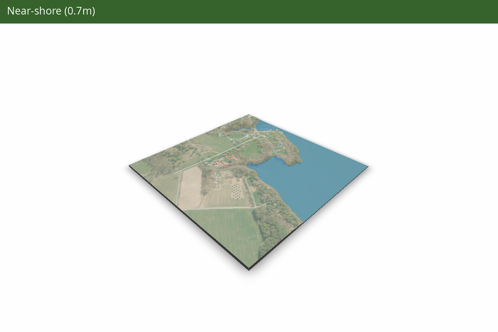

### Lake horizon (30m SRTM)

The full lake surface and far shore visible from the camera out to ~6 km.

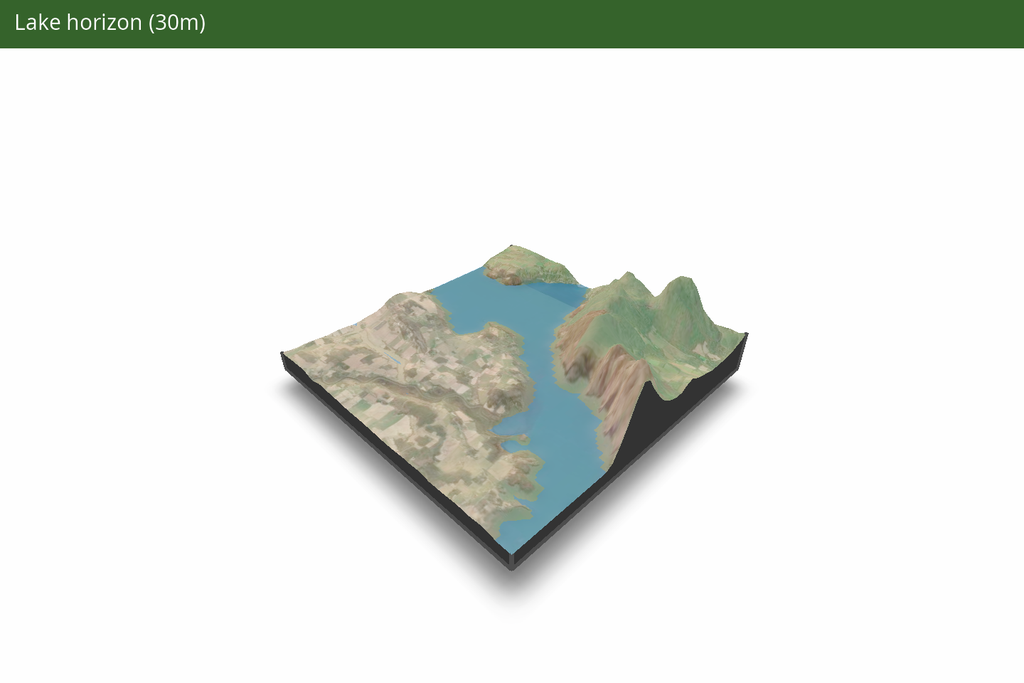

### Adirondack ridgeline (30m SRTM)

The New York mountain range across the lake — the dominant mid/far-ground feature in the northwest view.

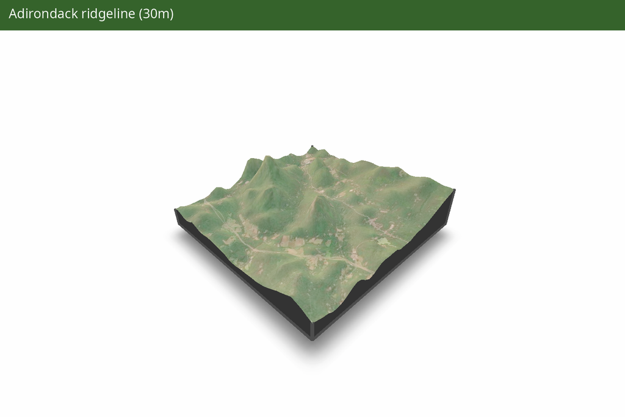

### Full scene (30m SRTM, 15 km)

Both shores and the lake basin combined — the extent used for the far terrainheightmap export.

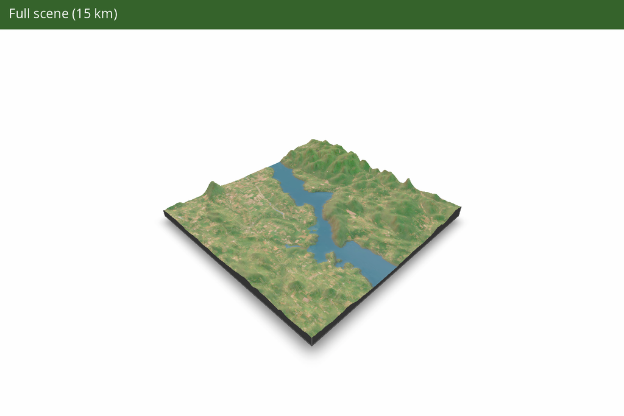